# Deterioro de Cartera

Diego Lesmes

14 de septiembre del 2020

## Objetivo

Desarrollar un modelo o modelos de deterioro de cartera que permitan generar un estimador según los **días de mora** de cada factura (A, B, C, D, E), para esto se debe mostrar en cada categoría cuál es la **probabilidad de no pago** de las mismas; este modelo debe mostrar los mejores resultados globales y una **parametrización por sector económico** del cliente.

### Lectura del conjunto de información

A continuación se describen las variables que contiene el conjunto de datos:

- A_Fecha: Fecha de corte para cálculo de días de mora
- ID: ID de factura en base de datos
- Nro_Factura: Número factura
- Fecha: Fecha emisión factura
- Fecha_Vto: Fecha vencimiento factura
- Saldo_a_Fecha: Saldo pendiente pago
- Mes: Consecutivo del mes histórico
- Estado: Categoría de clasificación de mora (1, 2, 3, 4, 5)
- Dias_mora: días de mora para el pago de la factura
- Sector: Sector económico al cual pertenece el cliente

## EDA

```r
summary(data)
```

```
##     A_FECHA                 ID         NRO_FACTURA            FECHA
##  Min.   :2015-08-31   Min.   : 15243   Length:438883      Min.   :1998-07-31
##  1st Qu.:2017-01-31   1st Qu.:371458   Class :character   1st Qu.:2016-09-30
##  Median :2018-02-28   Median :486813   Mode  :character   Median :2017-10-31
##  Mean   :2018-01-24   Mean   :496070                      Mean   :2017-08-16
##  3rd Qu.:2019-03-03   3rd Qu.:626125                      3rd Qu.:2018-09-30
##  Max.   :2019-12-31   Max.   :776610                      Max.   :2019-11-29
##    FECHA_VTO          SALDO_A_FECHA             MES            ESTADO
##  Min.   :1998-07-31   Min.   :-1.854e+06   Min.   : 1.00   Min.   :1.000
##  1st Qu.:2016-10-21   1st Qu.: 2.133e+05   1st Qu.:18.00   1st Qu.:1.000
##  Median :2017-11-20   Median : 8.779e+05   Median :31.00   Median :2.000
##  Mean   :2017-09-06   Mean   : 1.100e+07   Mean   :29.84   Mean   :2.232
##  3rd Qu.:2018-10-18   3rd Qu.: 1.732e+06   3rd Qu.:43.00   3rd Qu.:3.000
##  Max.   :2019-12-12   Max.   : 1.870e+12   Max.   :53.00   Max.   :5.000
##    Dias_mora         Sector           Categoria            Record
##  Min.   : -28.0   Length:438883      Length:438883      Length:438883
##  1st Qu.:   0.0   Class :character   Class :character   Class :character
##  Median :  35.0   Mode  :character   Mode  :character   Mode  :character
##  Mean   : 159.8
##  3rd Qu.: 127.0
##  Max.   :6697.0
```

Del resumen anterior podemos ver altos valores para las variables de Dias de mora y Saldo a la fecha:

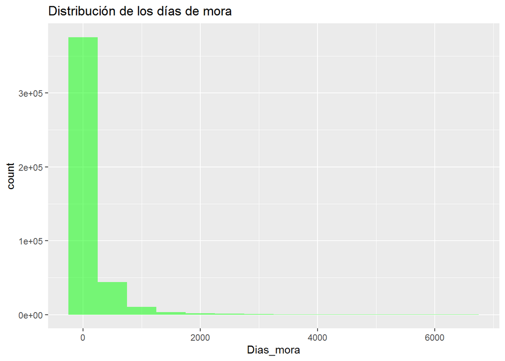

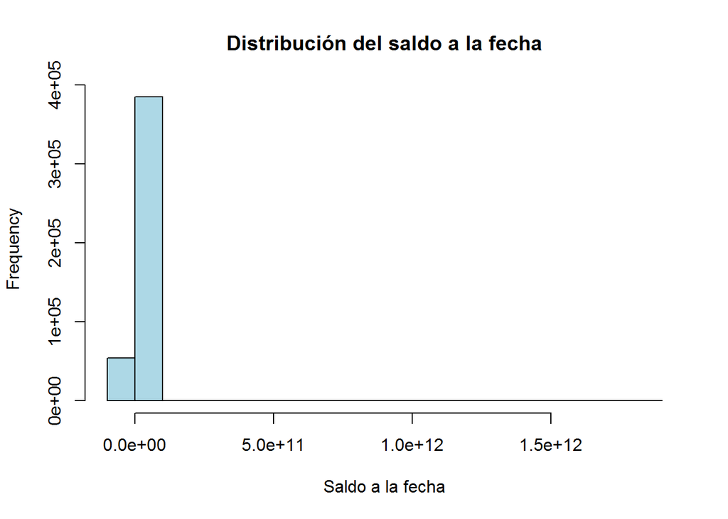

Efectivamente, se aprecia la presencia de atípicos, facturas con alrededor de 6000 dias de mora y facturas con saldos de 1.8 Billones de unidades monetarias, las siguientes gráficas nos confirman este hecho.

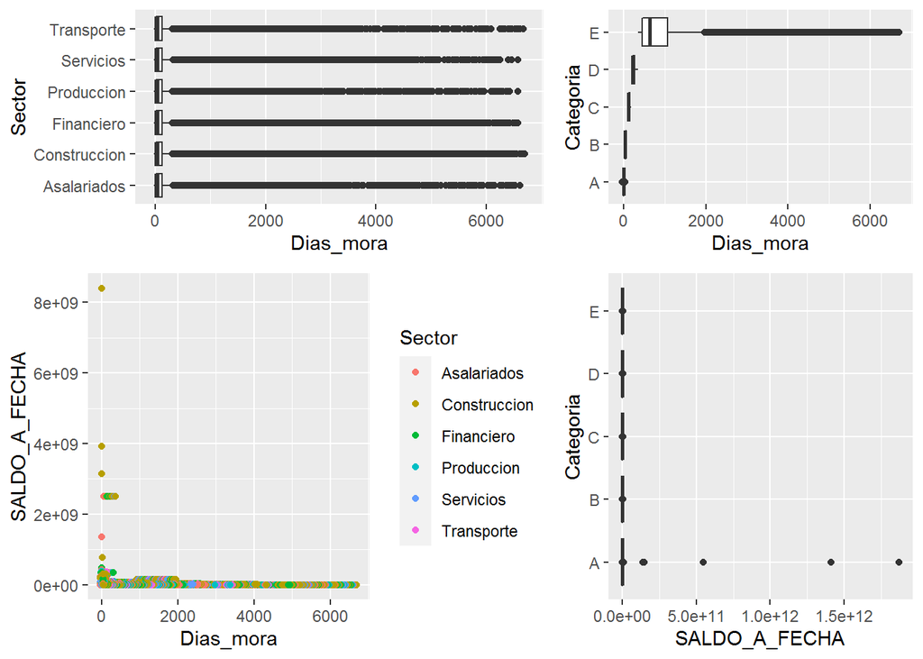

```
## # A tibble: 5 x 5
##   Categoria `Minimo#Dias` `Maximo#Dias` cantidad   `%`
##   <chr>             <dbl>         <dbl>    <int> <dbl>
## 1 A                     1            30    35853  8.17
## 2 B                    30            90   102002 23.2
## 3 C                    90           180    62430 14.2
## 4 D                   180           360    41894  9.55
## 5 E                   360          6697    47008 10.7
```

Sin embargo, podemos ver de que el conjunto de datos corresponde al seguimiento de todas las facturas, debido a que el total de facturas es menor al total de registros, indicando que hay varios registros para la misma factura; como se puede aprecia a continuación:

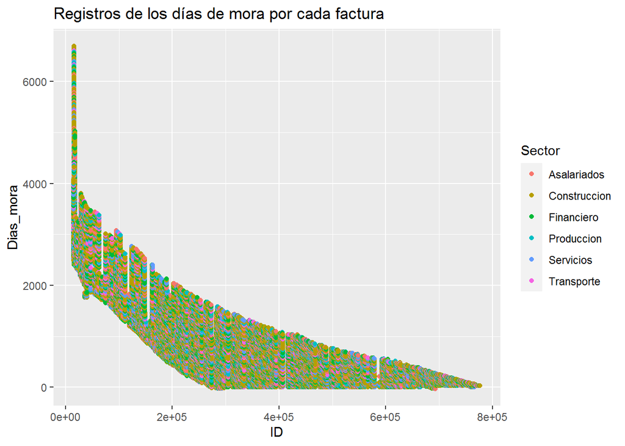

```
## [1] "A_FECHA" "53"
## [1] "ID"     "191073"
## [1] "NRO_FACTURA" "191073"
## [1] "FECHA" "1241"
## [1] "FECHA_VTO" "879"
## [1] "SALDO_A_FECHA" "108761"
## [1] "MES" "53"
## [1] "ESTADO" "5"
## [1] "Dias_mora" "2258"
## [1] "Sector" "6"
## [1] "Categoria" "5"
## [1] "Record" "191539"
```

## Probabilidad de no pago

Por lo cual definimos una tabla con las facturas vigentes, para proceder a realizar el análisis correspondiente, definiendo solamente las covariables a usar y una nueva covariable **“Pagado”** indicando si la factura tiene saldo o no.

```
##  SALDO_A_FECHA        Categoria           Sector      Pagado
##  Min.   :-1.854e+06   E:   508   Servicios   :19335   No:180940
##  1st Qu.: 3.999e+05   D:   346   Produccion  :19039   Si: 10133
##  Median : 8.930e+05   C:   594   Construccion:76234
##  Mean   : 2.333e+07   B: 23585   Financiero  :38414
##  3rd Qu.: 1.756e+06   A:166040   Transporte  :18915
##  Max.   : 1.870e+12              Asalariados :19136
```

De esta manera podemos visualizar la cantidad de facturas pagadas por Sector y por Categoría.

```
##
##         No     Si
##   E    508      0
##   D    344      2
##   C    465    129
##   B  13788   9797
##   A 165835    205
```

```
##
##                   No    Si
##   Servicios    18330  1005
##   Produccion   18007  1032
##   Construccion 72143  4091
##   Financiero   36388  2026
##   Transporte   17954   961
##   Asalariados  18118  1018
```

y la **probabilidad de no pago** por cada sector y cada Categoria.

```
##
##     Servicios Produccion Construccion Financiero Transporte Asalariados
##   E    100.00     100.00       100.00     100.00     100.00      100.00
##   D    100.00     100.00       100.00      98.78     100.00       97.37
##   C     78.69      75.00        78.12      80.91      75.76       79.71
##   B     58.02      59.06        58.11      58.22      60.30       58.36
##   A     99.86      99.84        99.87      99.90      99.88       99.92
```

## Modelo predictivo

Para empezar utilizaremos un modelo de Regresión logística y predecir si la factura sera pagada o no.

### Partición

Procedemos a hacer una partición para poder evaluar así la precisión de los modelos.

```r
test_index <- createDataPartition(fact$Pagado, times = 1, p = 0.5, list = FALSE)
train_set <- fact %>% slice(-test_index)
test_set <- fact %>% slice(test_index)
```

### Hot Encoding

Decodificamos las variables categoricas

```r
y <- train_set$Pagado
y_control <- test_set$Pagado
train_HEncod <- data.frame(predict(dummyVars(" ~ Categoria+Sector", data = train_set), newdata = train_set))
test_HEncod <- data.frame(predict(dummyVars(" ~ Categoria+Sector", data = test_set), newdata = test_set))
```

### Regresión Logística

```r
#Model_LR
Model_LR <- glm(y ~ ., data = train_HEncod, family = "binomial")
summary(Model_LR)
```

```
##
## Call:
## glm(formula = y ~ ., family = "binomial", data = train_HEncod)
##
## Deviance Residuals:
##     Min       1Q   Median       3Q      Max
## -1.0484  -0.0503  -0.0503  -0.0499   3.6708
##
## Coefficients: (2 not defined because of singularities)
##                     Estimate Std. Error z value Pr(>|z|)
## (Intercept)         -6.64596    0.11190 -59.392  < 2e-16 ***
## Categoria.E         -8.88583   94.53565  -0.094  0.92511
## Categoria.D          2.10900    0.71751   2.939  0.00329 **
## Categoria.C          5.29814    0.17172  30.854  < 2e-16 ***
## Categoria.B          6.33470    0.09988  63.422  < 2e-16 ***
## Categoria.A               NA         NA      NA       NA
## Sector.Servicios    -0.04207    0.08156  -0.516  0.60597
## Sector.Produccion   -0.05032    0.08063  -0.624  0.53255
## Sector.Construccion -0.02694    0.06368  -0.423  0.67229
## Sector.Financiero   -0.02916    0.07006  -0.416  0.67728
## Sector.Transporte   -0.09031    0.08100  -1.115  0.26489
## Sector.Asalariados        NA         NA      NA       NA
## ---
## Signif. codes:  0 '***' 0.001 '**' 0.01 '*' 0.05 '.' 0.1 ' ' 1
##
## (Dispersion parameter for binomial family taken to be 1)
##
##     Null deviance: 39616  on 95535  degrees of freedom
## Residual deviance: 17969  on 95526  degrees of freedom
## AIC: 17989
##
## Number of Fisher Scoring iterations: 14
```

En primera instancia podemos ver la **parametrización por sector productivo** de los clientes, con los coeficientes o valores esperados del modelo para cada categoria de la variable Sector economico, en segunda instancia vemos que esta variable de Sector economico precisamente, no es estadisticamente significativa, por sus altos p-Value, por otra parte el **AIC** del modelo tambien es alto.

### Métricas

Realizamos la predicción basado en el modelo anterior y en la regla de decisión definida mediante la gráfica de los datos de control.

```r
Prediction_LR <- predict(Model_LR,test_HEncod, type = "response", na.action = na.pass)
```

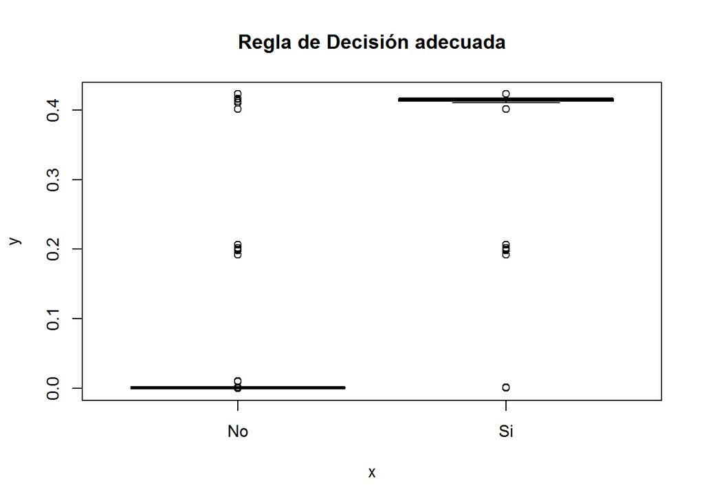

```r
plot(y_control,Prediction_LR, col = "light yellow",
     main = "Regla de Decisión adecuada")
```

```r
Prediction_LR_Fitted <- factor(ifelse(Prediction_LR < 0.2,'No','Si'))
confusionMatrix(Prediction_LR_Fitted,y_control)
```

```
## Confusion Matrix and Statistics
##
##           Reference
## Prediction    No    Si
##         No 83464   122
##         Si  7006  4945
##
##                Accuracy : 0.9254
##                  95% CI : (0.9237, 0.927)
##     No Information Rate : 0.947
##     P-Value [Acc > NIR] : 1
##
##                   Kappa : 0.5474
##
##  Mcnemar's Test P-Value : <2e-16
##
##             Sensitivity : 0.9226
##             Specificity : 0.9759
##          Pos Pred Value : 0.9985
##          Neg Pred Value : 0.4138
##              Prevalence : 0.9470
##          Detection Rate : 0.8736
##    Detection Prevalence : 0.8749
##       Balanced Accuracy : 0.9492
##
##        'Positive' Class : No
##
```

Podemos apreciar entonces las estadisticas de la matriz de confusión, que tenemos valores altos de Exactitud, sensitividad y especificidad.

## Navie Bayes

Se utilizan las particiones sin codificar para entrenar el modelo.

```r
fmla <- as.formula(paste("Pagado ~ ", paste("Categoria","Sector",sep = "+")))
Model_NB <- naiveBayes(fmla,data=train_set)
#summary(Model_NB)
```

Para este modelo, los **parámetros que definen el secor económico del cliente** son las *probabilidades de no pago* de esta variable, debido a que el modelo se basa en la probabilidad condicional determinada intrinsecamente por el conjunto de información.

### Métricas

Realizamos la predicción basado en las probabilidades del modelo

```r
Prediction_NB <- predict(object = Model_NB, newdata = test_set)
#Metrics
confusionMatrix(Prediction_NB, test_set$Pagado)
```

```
## Confusion Matrix and Statistics
##
##           Reference
## Prediction    No    Si
##         No 90470  5067
##         Si     0     0
##
##                Accuracy : 0.947
##                  95% CI : (0.9455, 0.9484)
##     No Information Rate : 0.947
##     P-Value [Acc > NIR] : 0.5037
##
##                   Kappa : 0
##
##  Mcnemar's Test P-Value : <2e-16
##
##             Sensitivity : 1.000
##             Specificity : 0.000
##          Pos Pred Value : 0.947
##          Neg Pred Value :   NaN
##              Prevalence : 0.947
##          Detection Rate : 0.947
##    Detection Prevalence : 1.000
##       Balanced Accuracy : 0.500
##
##        'Positive' Class : No
##
```

```r
#table(Prediction_NB, test_set$Pagado)
```

## Conclusiones

Se puede obtener un mayor **poder predictivo** para un conjunto de datos que contenga mas variables independientes que describan a las personas con obligaciones de pago, tales como, sexo, edad, Grado de escolaridad, estado civil, cantidad de hijos, Patrimonio, valor de la cuota, cantidad de cuotas, entre otras; de esta manera se puede realizar un estudio mas completo y descriptivo sobre la intención de pago de los deudores.

Por ultimo es preciso tener en cuenta que los resultados de los diferentes modelos a utilizar, pueden mejorarse si se agregan al estudio aquellas facturas pagadas oportunamente, de esta manera se puede tener una perspectiva adecuada del comportamiento de pago de la población, **evitando el desbalance** presentado en este ejercicio.

## Código Base

Se puede apreciar el código completo usado [acá](https://github.com/DLesmes/Dlesmes.github.io/blob/master/PortfolioImpairment/Cartera_Prueba.R)